# Final Project: The Olympics

Michelle Cryder, Collin Loy

December 14, 2018

# Introduction

- This dataset includes the names and characterics of olympic athletes from 1896-2016. Variables include personal statistics, (such as age, gender, height, and weight of each athlete), along with the sport, country, and medals received. There is another dataset that provides the National Olympic Committee code (NOC) and the corresponding geographical region. Source information about the dataset: https://www.kaggle.com/heesoo37/120-years-of-olympic-history-athletes-and-results/home

[figure not shown]

# Cleaning

- Throughout this project we used several different methods to clean and shape our data into the necessary formats.Joining the two tables our data set came with was the first step; We were able to use things like na.omit to get rid of blank results for certain graphs and were always filtering for specific results. The biggest ammount of reshaping we did was grouping our data into the necessary tables to get the results we needed.

# Data Exploration

```r
## Data Exploration:

# List of variables and their formats.
str(olympics)
```

```
## Classes 'tbl_df', 'tbl' and 'data.frame':    271116 obs. of  17 variables:
##  $ ID    : int  1 2 3 4 5 5 5 5 5 5 ...
##  $ Name  : chr  "A Dijiang" "A Lamusi" "Gunnar Nielsen Aaby" "Edgar Lindenau Aabye" ...
##  $ Sex   : chr  "M" "M" "M" "M" ...
##  $ Age   : int  24 23 24 34 21 21 25 25 27 27 ...
##  $ Height: int  180 170 NA NA 185 185 185 185 185 185 ...
##  $ Weight: num  80 60 NA NA 82 82 82 82 82 82 ...
##  $ Team  : chr  "China" "China" "Denmark" "Denmark/Sweden" ...
##  $ NOC   : chr  "CHN" "CHN" "DEN" "DEN" ...
##  $ Games : chr  "1992 Summer" "2012 Summer" "1920 Summer" "1900 Summer" ...
##  $ Year  : int  1992 2012 1920 1900 1988 1988 1992 1992 1994 1994 ...
##  $ Season: chr  "Summer" "Summer" "Summer" "Summer" ...
##  $ City  : chr  "Barcelona" "London" "Antwerpen" "Paris" ...
##  $ Sport : chr  "Basketball" "Judo" "Football" "Tug-Of-War" ...
##  $ Event : chr  "Basketball Men's Basketball" "Judo Men's Extra-Lightweight" "Football Men's Football" "Tug-Of-War Men's Tug-Of-War" ...
##  $ Medal : chr  NA NA NA "Gold" ...
##  $ region: chr  "China" "China" "Denmark" "Denmark" ...
##  $ notes : chr  NA NA NA NA ...
```

```r
# 5 number summaries of each variable.
summary(olympics)
```

```
##        ID             Name               Sex                 Age
##  Min.   :     1   Length:271116      Length:271116      Min.   :10.00
##  1st Qu.: 34643   Class :character   Class :character   1st Qu.:21.00
##  Median : 68205   Mode  :character   Mode  :character   Median :24.00
##  Mean   : 68249                                         Mean   :25.56
##  3rd Qu.:102097                                         3rd Qu.:28.00
##  Max.   :135571                                         Max.   :97.00
##                                                         NA's   :9474
##      Height          Weight          Team               NOC
##  Min.   :127.0   Min.   : 25.0   Length:271116      Length:271116
##  1st Qu.:168.0   1st Qu.: 60.0   Class :character   Class :character
##  Median :175.0   Median : 70.0   Mode  :character   Mode  :character
##  Mean   :175.3   Mean   : 70.7
##  3rd Qu.:183.0   3rd Qu.: 79.0
##  Max.   :226.0   Max.   :214.0
##  NA's   :60171   NA's   :62875
##     Games                Year         Season              City
##  Length:271116      Min.   :1896   Length:271116      Length:271116
##  Class :character   1st Qu.:1960   Class :character   Class :character
##  Mode  :character   Median :1988   Mode  :character   Mode  :character
##                     Mean   :1978
##                     3rd Qu.:2002
##                     Max.   :2016
##
##     Sport              Event              Medal
##  Length:271116      Length:271116      Length:271116
##  Class :character   Class :character   Class :character
##  Mode  :character   Mode  :character   Mode  :character
##
##
##
##
##     region             notes
##  Length:271116      Length:271116
##  Class :character   Class :character
##  Mode  :character   Mode  :character
##
##
##
##
```

```r
## Data Exploration: Summarize Variables

# Gender: Created a bar chart and filled by sex. There are over twice as many male athletes.
olympics %>% group_by(region, Sex) %>% count()
```

```
## # A tibble: 412 x 3
## # Groups:   region, Sex [412]
##    region         Sex       n
##    <chr>          <chr> <int>
##  1 Afghanistan    F         5
##  2 Afghanistan    M       121
##  3 Albania        F        27
##  4 Albania        M        43
##  5 Algeria        F        94
##  6 Algeria        M       457
##  7 American Samoa F         7
##  8 American Samoa M        30
##  9 Andorra        F        42
## 10 Andorra        M       127
## # ... with 402 more rows
```

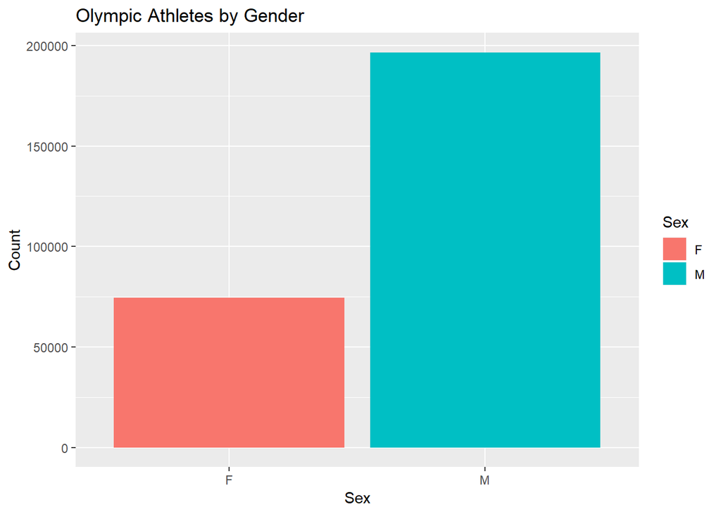

```r
olympics %>% ggplot(aes(x = Sex, fill = Sex)) + geom_bar() + ggtitle("Olympic Athletes by Gender") + ylab("Count")
```

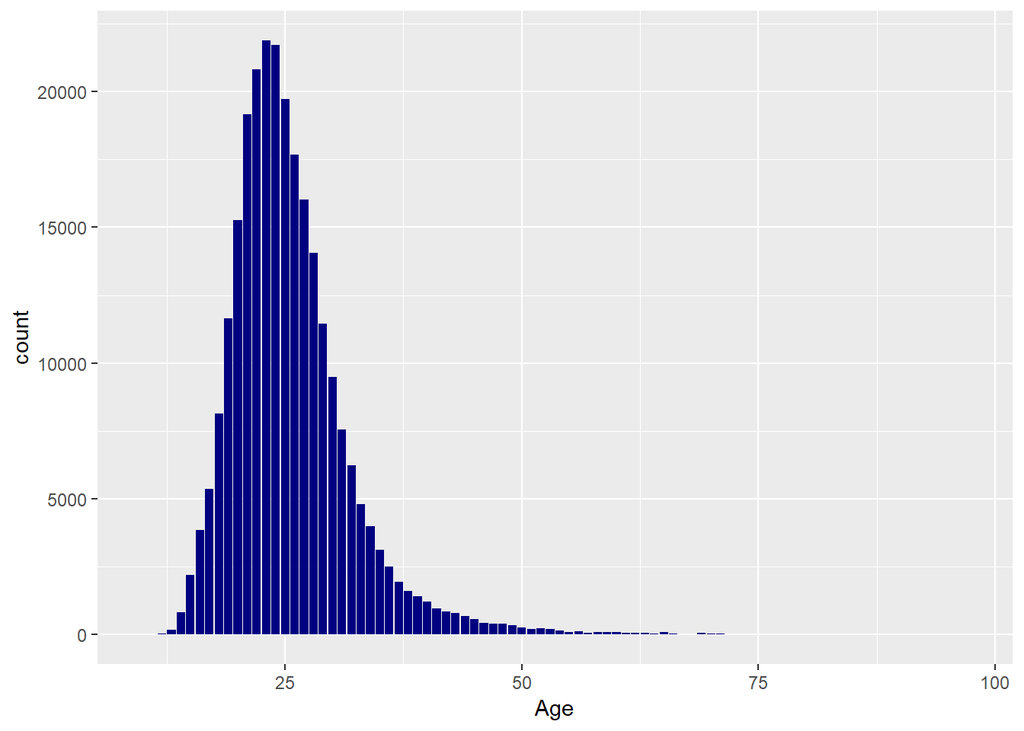

```r
# Age: For age, we summarized the average age by region, then created a histogram by region. We also created a histogram of all athelete ages. The plot is right-skewed, with 23 being the most common age.
olympics %>% ggplot(aes(x = Age)) + geom_bar(fill = "navy")
```

```r
olympics %>% group_by(region) %>% summarise(mean_age = mean(Age, na.rm=TRUE))
```

```
## # A tibble: 206 x 2
##    region         mean_age
##    <chr>             <dbl>
##  1 Afghanistan        23.5
##  2 Albania            25.3
##  3 Algeria            24.4
##  4 American Samoa     27.2
##  5 Andorra            23.1
##  6 Angola             24.9
##  7 Antigua            23.2
##  8 Argentina          25.9
##  9 Armenia            24.6
## 10 Aruba              24.9
## # ... with 196 more rows
```

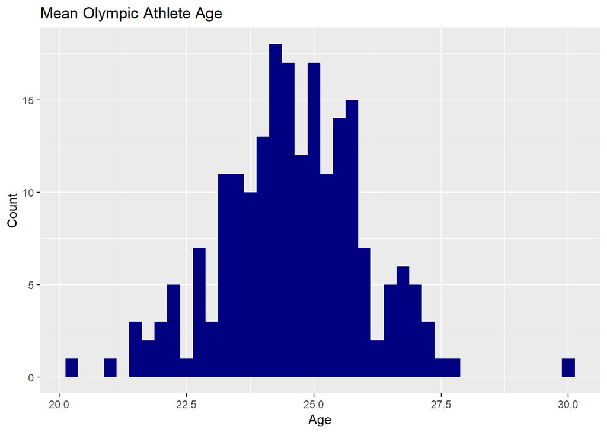

```r
olympics %>% group_by(region) %>% summarise(mean_age = mean(Age, na.rm=TRUE)) %>% ggplot(aes(mean_age)) + geom_histogram(binwidth = 0.25, fill = "navy") + xlab("Age") + ylab("Count") + ggtitle("Mean Olympic Athlete Age")
```

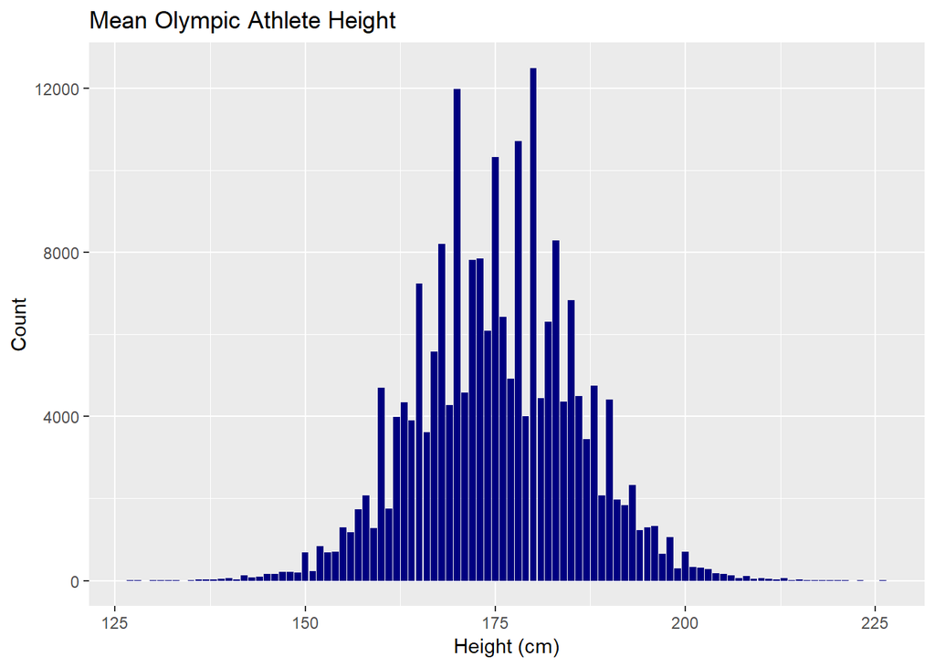

```r
# Height: For height, we summarized the average height by region, and created a histogram of all athlete heights. The plot shows a normal distribution, with the mean height at 175 cm.
olympics %>% ggplot(aes(x = Height)) + geom_bar(fill = "navy") + xlab("Height (cm)") + ylab("Count") + ggtitle("Mean Olympic Athlete Height")
```

```r
olympics %>% group_by(region) %>% summarise(mean_height = mean(Height, na.rm=TRUE))
```

```
## # A tibble: 206 x 2
##    region         mean_height
##    <chr>                <dbl>
##  1 Afghanistan           171.
##  2 Albania               173
##  3 Algeria               175.
##  4 American Samoa        176.
##  5 Andorra               174.
##  6 Angola                178.
##  7 Antigua               175.
##  8 Argentina             177.
##  9 Armenia               172.
## 10 Aruba                 173.
## # ... with 196 more rows
```

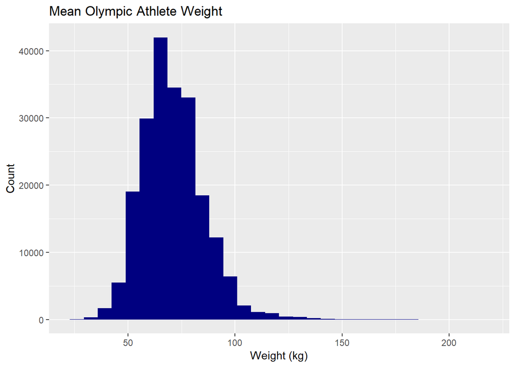

```r
# Weight: We did the same summarization for weight as height. This plot is right skewed, with the average olympic weight at around 70 kg.
olympics %>% ggplot(aes(Weight)) + geom_histogram(fill = "navy") + xlab("Weight (kg)") + ylab("Count") + ggtitle("Mean Olympic Athlete Weight")
```

```r
olympics %>% group_by(region) %>% summarise(mean_weight = mean(Weight, na.rm=TRUE))
```

```
## # A tibble: 206 x 2
##    region         mean_weight
##    <chr>                <dbl>
##  1 Afghanistan           65.9
##  2 Albania               71.5
##  3 Algeria               68.7
##  4 American Samoa        88.0
##  5 Andorra               70.6
##  6 Angola                74.1
##  7 Antigua               66.2
##  8 Argentina             74.0
##  9 Armenia               73.1
## 10 Aruba                 71.2
## # ... with 196 more rows
```

```r
# Regions: Created a summary of the number of the athletes from each region
olympics %>% group_by(region) %>% count()
```

```
## # A tibble: 206 x 2
## # Groups:   region [206]
##    region             n
##    <chr>          <int>
##  1 Afghanistan      126
##  2 Albania           70
##  3 Algeria          551
##  4 American Samoa    37
##  5 Andorra          169
##  6 Angola           267
##  7 Antigua          133
##  8 Argentina       3297
##  9 Armenia          221
## 10 Aruba             42
## # ... with 196 more rows
```

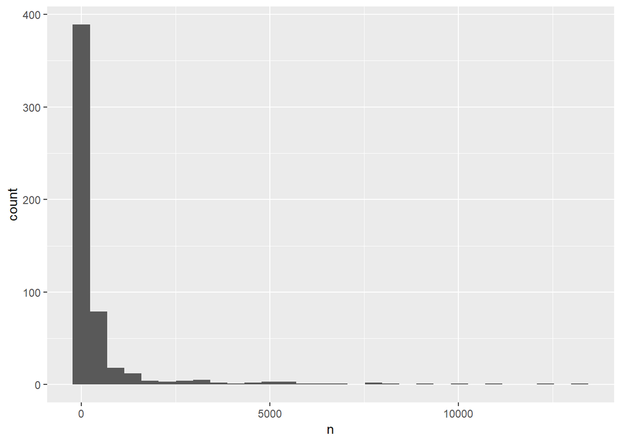

```r
names = olympics %>% group_by(region, Name) %>% select(Name, region)

# Medals: Looking at the number of medals by region.
olympics %>% group_by(region, Medal) %>% count() %>% ggplot(aes(n)) + geom_histogram()
```

- All of the visual summaries for each variable match expectations. The variability in average age over time was somewhat surprising.